# Whole Names Visualization

## Visualization Part II: All Baby Names

### Overview:

In this section, we will include the visualization and result discussion for the analysis using all baby names.

(1) The first part of the analysis is using PC1 and PC2 of the cross-corelation matrix to separate the 51 states, and based on the projection of PC1, PC2 to choose the reasonable number of clusters. Then we uses Hierarchical Clustering, K-Means Clustering (related code in Hierarchical Clustering & K-Means Clustering section) to cluster 51 states.

(2) The visulization in this section includes (i) How to choose number of clusters (ii) Using Tableau to reflect the state-clusters in a map view (Tableau may not able to be shown in github, but it can be view on Ipython Notebook, and we will embed Tableau stories in the website)

### Import the organized PCA data from previous steps

```python
# -*- coding: utf-8 -*-
from __future__ import division
import numpy as np
import pandas as pd
from sklearn import linear_model
import matplotlib
import matplotlib.pyplot as plt
from sklearn.metrics import r2_score
from sklearn.cross_validation import train_test_split
import matplotlib.cm as cmx
import matplotlib.colors as colors
from sklearn.decomposition import PCA
import pickle
from sklearn import preprocessing
%matplotlib inline
```

```python
with open('data_matrix_event.pkl', 'rb') as f:
    [df_WWII_before, df_WWII_after, df_depression_before, df_depression_after, df_fe_before, df_fe_after, df_ma_before, df_ma_after, df_alaska_before, df_alaska_after] = pickle.load(f)
f.close()
```

```python
#Function: corrstate: compute state by state corrleation between the fluctuations of the frequencies of the names over the states
#Input: df: dataframe has states as rows and biblical names as columns for each year
#Return: corr_matrix: matrix contains the Pearson correlation between the flucuations of name in state i and state j
#        for all states in the fluctuation;
def corrstate(df):
    #sum the count of name by states
    total_sum = df.sum(axis = 1)
    #divide the count of name in each state by the previous sum
    df1 = df.div(total_sum.ix[0],axis='columns')
    statenum = df1.shape[0]
    name_sum = df1.sum(axis = 0)
    #count the average frequency of name over the states
    averfreq = name_sum/float(statenum)
    #use the frequency of name in the state - average frequency of the name over states (he flucuations of name)
    fluctuation = df1.subtract(averfreq, axis ='columns')
    #compute the Pearson correlation among 51 states * 51 states
    return np.corrcoef(fluctuation)
```

```python
#Function: PCAcorr: use PC1, 2 to figure out the separate the noise from true system dynamics
#          Based on the assumption that the PC1, PC2 are related to true similarity
#Input: corr_matrix: Pearson correlation between the flucuations of name over states
#Return: corr_reduced: generated correlation matrix after reducing by PCA

def PCAcorr(corr_matrix):
    corr_matrix = preprocessing.normalize(corr_matrix)
    pca = PCA(n_components=2)
    pca.fit(corr_matrix)
    corr_reduced = pca.transform(corr_matrix)
    return corr_reduced
```

```python
#Function: convert the origianl correlation matrix into a positive definite matrix
#Input: corr_matrix: the origianl correlation matrix
#Return: converted correlation matrix
def converted_corr(corr_matrix):
    coverted_corr = (corr_matrix + 1)/2
    return coverted_corr
```

```python
PCA_WWII_before = PCAcorr(corrstate(df_WWII_before))
PCA_WWII_after = PCAcorr(corrstate(df_WWII_after))

PCA_depression_before = PCAcorr(corrstate(df_depression_before))
PCA_depression_after = PCAcorr(corrstate(df_depression_after))

PCA_feminism_fe_before = PCAcorr(corrstate(df_fe_before))
PCA_feminism_fe_after = PCAcorr(corrstate(df_fe_after))

PCA_feminism_ma_before = PCAcorr(corrstate(df_ma_before))
PCA_feminism_ma_after = PCAcorr(corrstate(df_ma_after))

PCA_alaska_before = PCAcorr(corrstate(df_alaska_before))
PCA_alaska_after = PCAcorr(corrstate(df_alaska_after))
```

```python
PCA=[]
PCA.append(PCA_WWII_before)
PCA.append(PCA_WWII_after)
PCA.append(PCA_depression_before)
PCA.append(PCA_depression_after)
PCA.append(PCA_feminism_fe_before)
PCA.append(PCA_feminism_fe_after)
PCA.append(PCA_feminism_ma_before)
PCA.append(PCA_feminism_ma_after)
PCA.append(PCA_alaska_before)
PCA.append(PCA_alaska_after)
```

### Choose number of K (clusters) using the plot of projection of PC1 and PC2

#### PC1, PC2 of Correlation matrix for 51 states over years

```python
#Function: Sort PC1 in descending order and assign each state a different color
#          Visualize the PC1,2 distribution for each state
#Input: pc12: Correlation matrix after reducing by PCA (which is based on the first two principle component of biblical names for each state)
#Input: title: the year that the data come from
#Input: i: column index for data visualization
#Input: ax_ind: row index for data visualizaion

def plot_pca_year_multi(pc12, title, i,ax_ind):
    # sort pca
    pc12=pc12[np.lexsort(([1,-1]*pc12[:,[1,0]]).T)]
    # split pc1, pc2
    pc1=pc12[:,0]
    pc2=pc12[:,1]
    # Plot data
    cs = matplotlib.cm.rainbow(np.linspace(0, 1, len(pc12)))
    ax[i][ax_ind].scatter(pc1,pc2,label='pc1 pc2',color=cs)
    # Label axes, set title
    ax[i][ax_ind].set_title(title,fontsize=15)
    ax[i][ax_ind].set_xlabel('$V^{(2)}$',fontsize=15)
    ax[i][ax_ind].set_ylabel('$V^{(1)}$',fontsize=15)
    ax[i][ax_ind].set_xlim(-1,1.5)
    ax[i][ax_ind].set_ylim(-1,1.5)
```

```python
title=["PCA_WWII_before","PCA_WWII_after","PCA_depression_before","PCA_depression_after","PCA_feminism_fe_before","PCA_feminism_fe_after","PCA_feminism_ma_before","PCA_feminism_ma_after","PCA_alaska_before","PCA_alaska_after"]
```

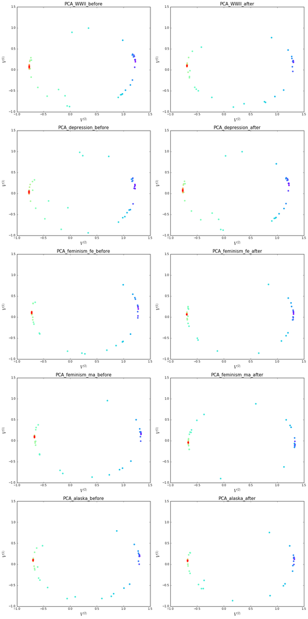

```python
fig, ax = plt.subplots(5, 2, figsize=(15,30 ))

#Start the index of the current subplot at 0
ax_ind = 0
ix=0
for j in range(0,5):
    ax_ind = j
    ix=ix
    #Iterate through all the shapes
    for i in range (0,2):
        pc12=PCA[ix]
        plot_pca_year_multi(pc12,str(title[ix]),ax_ind,i)
        ix+=1

plt.tight_layout()
plt.show()
```

**PC1 & PC2 visualization**

- We take the first two principle component from PCA for each event (which was calculated based on the matrices that consist of the correlation of distribution of whole baby names in state I and and that in state j). And then we reorder the array (of the PC1, PC2) in the descending order of PC1 and then assign rainbow color.
- We found that there are 3 clusters (in general, the colors can be separated into three groups) in every PC1/PC2 plots above for 10 matrices. Therefore, we use 3 cluster for hierarchical clustering and K-means clustering to group states. States in the similar groups are going to be assigned similar colors in tableau visualization. The overlap between these points here could be used to describe the similarities movement of populations before and after such event. Instead of considering these overlaps in time, we consider the correlations between states on each event, by studying the whole distribution of baby names in every state.

#### US map

```python
idx=['AK', 'AL', 'AR', 'AZ', 'CA', 'CO', 'CT', 'DC', 'DE', 'FL','GA', 'HI', 'IA', 'ID', 'IL', 'IN', 'KS', 'KY', 'LA', 'MA','MD', 'ME', 'MI', 'MN', 'MO', 'MS', 'MT', 'NC', 'ND', 'NE','NH', 'NJ', 'NM', 'NV', 'NY', 'OH', 'OK', 'OR', 'PA', 'RI','SC', 'SD', 'TN', 'TX', 'UT', 'VA', 'VT', 'WA', 'WI', 'WV','WY']
```

```python
def generate_table(title,idx):
    n=len(title)
    j=0
    pc=PCA[j]
    df=pd.DataFrame(pc)
    df['idx']=idx
    df = df.set_index(['idx'])
    del df.index.name
    df.columns = ['pc1', 'pc2']
    sorted_df=df.sort('pc1',ascending=False)
    cs = matplotlib.cm.rainbow(np.linspace(0, 1, len(df)))
    color=cs[:,:-1]*255
    row=color.shape[0]
    new_color=[]

    for i in range(0,row):
        a=color[i]
        r=a[0]
        g=a[1]
        b=a[2]
        rgb=65536 * r + 256 * g + b
        new_color.append(rgb)

    YEAR=str(title[j])
    sorted_df[YEAR]=new_color
    table0=pd.DataFrame(sorted_df[YEAR])


    for j in range(1,n):
        pc=PCA[j]
        df=pd.DataFrame(pc)
        df['idx']=idx
        df = df.set_index(['idx'])
        del df.index.name
        df.columns = ['pc1', 'pc2']
        sorted_df=df.sort('pc1',ascending=False)
        cs = matplotlib.cm.rainbow(np.linspace(0, 1, len(df)))
        color=cs[:,:-1]*255
        row=color.shape[0]
        new_color=[]

        for i in range(0,row):
            a=color[i]
            r=a[0]
            g=a[1]
            b=a[2]
            rgb=65536 * r + 256 * g + b
            new_color.append(rgb)

        YEAR=str(title[j])
        sorted_df[YEAR]=new_color
        table1=pd.DataFrame(sorted_df[YEAR])
        table0=pd.concat([table0,table1],axis=1)


    return table0
```

```python
table=generate_table(title,idx)
table.head()
```

|  | PCA_WWII_before | PCA_WWII_after | PCA_depression_before | PCA_depression_after | PCA_feminism_fe_before | PCA_feminism_fe_after | PCA_feminism_ma_before | PCA_feminism_ma_after | PCA_alaska_before | PCA_alaska_after |
| --- | --- | --- | --- | --- | --- | --- | --- | --- | --- | --- |
| AK | 1.450567e+07 | 1.673902e+07 | 1.372171e+07 | 1.450567e+07 | 1.450567e+07 | 1.671972e+07 | 1.674263e+07 | 1.675634e+07 | 1.674680e+07 | 1.671168e+07 |
| AL | 3.104964e+06 | 3.762135e+06 | 2.316074e+06 | 3.104964e+06 | 3.762135e+06 | 4.419080e+06 | 3.762135e+06 | 4.419080e+06 | 4.419080e+06 | 5.075795e+06 |
| AR | 7.700261e+06 | 9.796999e+06 | 7.700261e+06 | 7.700261e+06 | 7.700261e+06 | 1.045171e+07 | 9.796999e+06 | 9.796999e+06 | 9.142040e+06 | 9.796999e+06 |
| AZ | 1.675634e+07 | 1.674263e+07 | 1.674680e+07 | 1.675634e+07 | 1.306817e+07 | 1.646429e+07 | 1.673151e+07 | 1.673531e+07 | 1.581161e+07 | 1.673531e+07 |
| CA | 4.447513e+06 | 5.750576e+06 | 3.144091e+06 | 4.447513e+06 | 7.053397e+06 | 5.750576e+06 | 6.402009e+06 | 5.099082e+06 | 5.750576e+06 | 5.750576e+06 |

```python
table.to_csv('wholebabynames_pca_tableau.csv')
```

```python
table=pd.read_csv("wholebabynames_pca_tableau.csv")
```

```python
writer = pd.ExcelWriter('wholebabynames_pca_tableau.xlsx', engine='xlsxwriter')
table.to_excel(writer, sheet_name='pca',index = False,header=True)
writer.save()
```

### Hierachical clustering

```python
HC=pd.read_csv("HC_Latest.csv")
HC.head()
```

|  | state | WWII_before | WWII_after | depression_before | depression_after | feminism_fe_before | feminism_fe_after | feminism_ma_before | feminism_ma_after | alaska_before | alaska_after |
| --- | --- | --- | --- | --- | --- | --- | --- | --- | --- | --- | --- |
| 0 | AK | 1 | 0 | 1 | 1 | 0 | 1 | 1 | 0 | 0 | 1 |
| 1 | AL | 0 | 2 | 0 | 0 | 2 | 2 | 0 | 0 | 2 | 2 |
| 2 | AR | 2 | 0 | 2 | 2 | 0 | 1 | 1 | 0 | 0 | 1 |
| 3 | AZ | 1 | 0 | 1 | 1 | 0 | 1 | 1 | 0 | 0 | 1 |
| 4 | CA | 0 | 1 | 0 | 0 | 1 | 0 | 2 | 2 | 1 | 0 |

```python
writer = pd.ExcelWriter('wholebabynames_HC_tableau.xlsx', engine='xlsxwriter')
HC.to_excel(writer, sheet_name='HC')
writer.save()
```

link: https://public.tableau.com/views/HC-wholebabynames/Story1?:embed=y&:display_count=yes

```python
%%html
<div class='tableauPlaceholder' id='viz1481582901208' style='position: relative'><noscript><a href='#'><img alt='&lt;HC-whole baby names&gt; ' src='https:&#47;&#47;public.tableau.com&#47;static&#47;images&#47;HC&#47;HC-wholebabynames&#47;Story1&#47;1_rss.png' style='border: none' /></a></noscript><object class='tableauViz'  style='display:none;'><param name='host_url' value='https%3A%2F%2Fpublic.tableau.com%2F' /> <param name='site_root' value='' /><param name='name' value='HC-wholebabynames&#47;Story1' /><param name='tabs' value='no' /><param name='toolbar' value='yes' /><param name='static_image' value='https:&#47;&#47;public.tableau.com&#47;static&#47;images&#47;HC&#47;HC-wholebabynames&#47;Story1&#47;1.png' /> <param name='animate_transition' value='yes' /><param name='display_static_image' value='yes' /><param name='display_spinner' value='yes' /><param name='display_overlay' value='yes' /><param name='display_count' value='yes' /></object></div>                <script type='text/javascript'>                    var divElement = document.getElementById('viz1481582901208');                    var vizElement = divElement.getElementsByTagName('object')[0];                    vizElement.style.width='1020px';vizElement.style.height='1033px';                    var scriptElement = document.createElement('script');                    scriptElement.src = 'https://public.tableau.com/javascripts/api/viz_v1.js';                    vizElement.parentNode.insertBefore(scriptElement, vizElement);                </script>
```

[figure not shown]

### K means clustering

```python
KM=pd.read_csv("KMEANS_Latest.csv")
KM.head()
```

|  | state | WWII_before | WWII_after | depression_before | depression_after | feminism_fe_before | feminism_fe_after | feminism_ma_before | feminism_ma_after | alaska_before | alaska_after |
| --- | --- | --- | --- | --- | --- | --- | --- | --- | --- | --- | --- |
| 0 | AK | 0 | 0 | 2 | 0 | 0 | 1 | 1 | 0 | 0 | 1 |
| 1 | AL | 1 | 2 | 1 | 2 | 2 | 2 | 2 | 2 | 2 | 0 |
| 2 | AR | 2 | 0 | 0 | 2 | 0 | 1 | 1 | 0 | 0 | 1 |
| 3 | AZ | 0 | 0 | 2 | 0 | 0 | 1 | 1 | 0 | 0 | 1 |
| 4 | CA | 1 | 1 | 1 | 1 | 1 | 0 | 0 | 1 | 1 | 2 |

```python
writer = pd.ExcelWriter('wholebabynames_KM_tableau.xlsx', engine='xlsxwriter')
KM.to_excel(writer, sheet_name='KM')
writer.save()
```

ink: https://public.tableau.com/views/Wholebabynames-HC/Story1?:embed=y&:display_count=yes

```python
%%html
<div class='tableauPlaceholder' id='viz1481579922045' style='position: relative'><noscript><a href='#'><img alt='&lt;KM - whole baby names&gt; ' src='https:&#47;&#47;public.tableau.com&#47;static&#47;images&#47;Wh&#47;Wholebabynames-HC&#47;Story1&#47;1_rss.png' style='border: none' /></a></noscript><object class='tableauViz'  style='display:none;'><param name='host_url' value='https%3A%2F%2Fpublic.tableau.com%2F' /> <param name='site_root' value='' /><param name='name' value='Wholebabynames-HC&#47;Story1' /><param name='tabs' value='no' /><param name='toolbar' value='yes' /><param name='static_image' value='https:&#47;&#47;public.tableau.com&#47;static&#47;images&#47;Wh&#47;Wholebabynames-HC&#47;Story1&#47;1.png' /> <param name='animate_transition' value='yes' /><param name='display_static_image' value='yes' /><param name='display_spinner' value='yes' /><param name='display_overlay' value='yes' /><param name='display_count' value='yes' /></object></div>                <script type='text/javascript'>                    var divElement = document.getElementById('viz1481579922045');                    var vizElement = divElement.getElementsByTagName('object')[0];                    vizElement.style.width='1020px';vizElement.style.height='1033px';                    var scriptElement = document.createElement('script');                    scriptElement.src = 'https://public.tableau.com/javascripts/api/viz_v1.js';                    vizElement.parentNode.insertBefore(scriptElement, vizElement);                </script>
```

[figure not shown]

**Graphing maps**

Observed Pattern:

Before and after Alaska become a state: GA and FL changed from similar to different from nearby states like LA, AL, TN, KY.

Before and after Great Depression: TN, GA, AL have been influenced by nearby states

Before and after the second wave feminism (female names): GA, FL, NC changed from being similar to different from nearby states like AL,LA

Before and after the second wave feminism (male names): FL changed from being similar to different from nearby states, like GA, TN, NC.

Before and after the WWII: An infusion of South and nearby states (and California).

**The further discussion will be included in the Tabluea Visualization & Result Discussion section**